# Which Data & AI Role Is the Best Entry Point?

An evidence-based audit of untruncated entry-level and internship job descriptions

Author

Pablo

Published

November 23, 2026

# 1 Executive summary

This report audits 636 deduplicated, full-text job postings ($\ge 1{,}000$ description characters; mean length 6,228 characters) across four career tracks: Data Analyst, Data Scientist, ML Engineer, and AI Engineer. By filtering out short API preview snippets (< 1,000 characters) from `raw_jobs`, keyword extraction captures complete Requirements and Qualifications sections rather than truncated headlines.

After separating postings that lacked explicit senior titles in raw ATS feeds, or matched junior queries despite requiring 4+ years of experience (448 postings, 70.4%), 188 verified Intern and Junior / Entry-Level postings (29.6%) remain in the core analysis scope.

**Note**

**Data snapshot & scope:** The most recent posting date in the dataset is 2026-11-22. To prevent false-negative skill counts caused by free-tier snippet truncation, `clean_jobs` enforces `LENGTH(description_snippet) >= 1000`, focusing the analytical sample on full-text public ATS and API postings.

# 2 Project vision and method

## 2.1 Research questions

1. **Role demand and accessibility:** How do verified entry-level and internship volumes compare across the four titles once mid/senior roles are filtered out?
2. **Skill overlap vs. specialization:** Which technical skills are universal across tracks, and which stacks define each specialization when full descriptions are parsed?
3. **Credential and experience barriers:** How many junior/intern postings require a Master’s/PhD or 2+ years of prior experience?
4. **Compensation and work mode:** How do disclosed salaries and remote/hybrid availability differ across roles?

## 2.2 Pipeline

```
flowchart LR
  A["Official Job APIs and<br/>Public ATS Feeds"] --> B[("Postgres<br/>raw_jobs")]
  B --> C["sql/01_clean_and_normalize.sql<br/>≥1,000 char filter, dedupe, regex"]
  C --> D[("clean_jobs<br/>n = 636 full-text")]
  D --> E["sql/02_market_analysis.sql<br/>analytical views"]
  D --> F["R/02_export_for_tableau.R"]
  F --> G["jobs_cleaned.csv<br/>Tableau Public"]
  F --> H["This report"]
```

[output not shown]

| Step | What happens |
| --- | --- |
| **Collection** | Multi-source ingestion via official REST APIs (Adzuna) and public ATS JSON endpoints (Greenhouse, Lever, Ashby, The Muse) into `raw_jobs` |
| **Quality Gate** | Retains postings with `LENGTH(description_snippet) >= 1000` so regex parsers evaluate full requirement lists rather than truncated snippets |
| **Deduplication** | One row per company + normalized title + location, preferring rows with listed salary and longer descriptions |
| **Role & Seniority** | Title-first regex taxonomy into 4 roles; separates Intern, Junior / Entry-Level, and Mid/Senior Mislabeled (senior title keywords or 4+ years experience) |
| **Feature Engineering** | Case-insensitive PostgreSQL regex (`~*`) flags across 16 technical skills, experience tier, degree tier, and work mode |

# 3 Q1. Role demand and accessibility

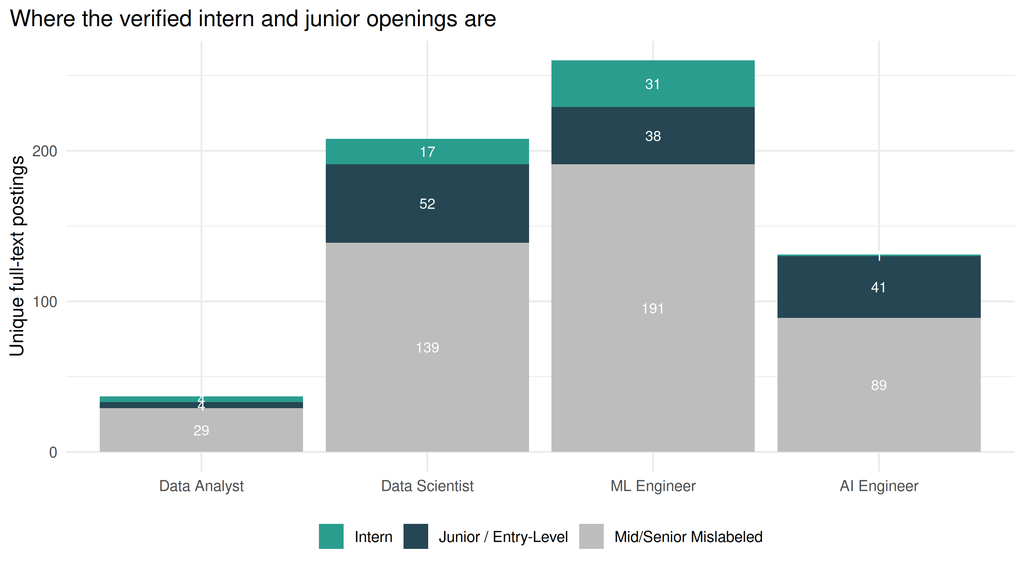

Figure 1: Full-text postings by role and seniority tier. Grey bars are postings that lacked senior titles in raw ATS feeds but contained senior keywords or 4+ year experience requirements.

```r
jobs |>
  count(normalized_role, seniority_tier, .drop = FALSE) |>
  ggplot(aes(normalized_role, n, fill = seniority_tier)) +
  geom_col() +
  geom_text(aes(label = if_else(n > 0, comma(n), "")),
            position = position_stack(vjust = 0.5), size = 3.2, colour = "white") +
  scale_fill_manual(values = c("Intern" = "#2a9d8f",
                               "Junior / Entry-Level" = "#264653",
                               "Mid/Senior Mislabeled" = "#bdbdbd"),
                    name = NULL) +
  labs(x = NULL, y = "Unique full-text postings",
       title = "Where the verified intern and junior openings are")
```

```r
jobs |>
  group_by(normalized_role) |>
  summarise(
    `Total postings`  = n(),
    `Intern`          = sum(seniority_tier == "Intern"),
    `Junior`          = sum(seniority_tier == "Junior / Entry-Level"),
    `Intern + Junior` = sum(seniority_tier %in% c("Intern", "Junior / Entry-Level")),
    `Mid/Senior rate` = percent(mean(seniority_tier == "Mid/Senior Mislabeled"), accuracy = 0.1),
    `Explicit 0-1 yr` = sum(seniority_tier %in% c("Intern", "Junior / Entry-Level") &
                              experience_tier == "0-1 Years / Entry"),
    .groups = "drop"
  ) |>
  rename(Role = normalized_role) |>
  kable(caption = "Accessibility summary across full-text postings. 'Mid/Senior rate' measures roles requiring 4+ years or senior titles.")
```

Table 1: Accessibility summary across full-text postings. ‘Mid/Senior rate’ measures roles requiring 4+ years or senior titles.

| Role | Total postings | Intern | Junior | Intern + Junior | Mid/Senior rate | Explicit 0-1 yr |
| --- | --- | --- | --- | --- | --- | --- |
| Data Analyst | 37 | 4 | 4 | 8 | 78.4% | 1 |
| Data Scientist | 208 | 17 | 52 | 69 | 66.8% | 2 |
| ML Engineer | 260 | 31 | 38 | 69 | 73.5% | 1 |
| AI Engineer | 131 | 1 | 41 | 42 | 67.9% | 1 |

**Reading this:** Because public ATS boards (Greenhouse, Lever, Ashby) publish every open role at tech/AI companies without pre-filtering by seniority, 70.4% (448 / 636) of full-text postings fall into Mid/Senior Mislabeled, highest in Data Analyst (78.4%) and ML Engineer (73.5%). Within verified Intern + Junior openings (n = 188), ML Engineer (31 Intern, 38 Junior) and Data Scientist (17 Intern, 52 Junior) provide the largest pools, while AI Engineer (1 Intern, 41 Junior) skews almost entirely toward full-time junior hires.

# 4 Q2. Skill overlap vs. specialization

All skill percentages below use verified Intern + Junior postings only (n = 188). Data Analyst has a small in-scope sample (n = 8), so percentages for that column should be interpreted directionally.

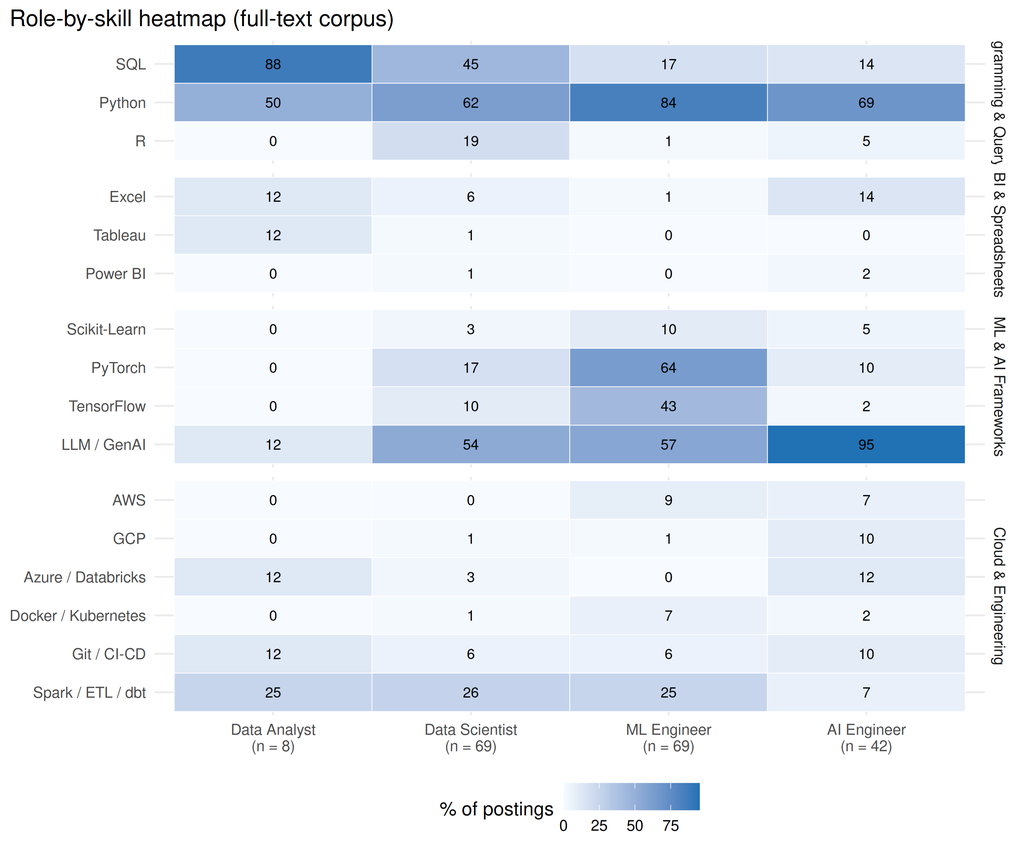

Figure 2: Share of verified Intern + Junior full-text postings mentioning each skill, by role.

```r
role_n <- scope |> count(normalized_role, .drop = FALSE) |>
  mutate(role_lab = paste0(normalized_role, "\n(n = ", n, ")"))

skill_pct |>
  left_join(role_n, by = "normalized_role") |>
  mutate(role_lab = fct_reorder(role_lab, as.integer(normalized_role))) |>
  ggplot(aes(role_lab, fct_rev(factor(skill_label, levels = skill_meta$skill_label)), fill = pct)) +
  geom_tile(colour = "white") +
  geom_text(aes(label = round(pct)), size = 3.2) +
  facet_grid(domain ~ ., scales = "free_y", space = "free_y") +
  scale_fill_gradient(low = "#f7fbff", high = "#2171b5", name = "% of postings") +
  labs(x = NULL, y = NULL, title = "Role-by-skill heatmap (full-text corpus)")
```

## 4.1 Universal vs. role-specific skill tiers

```r
universal_cut <- 14   # reaches at least ~14-15% in every role
spread_cut    <- 25   # percentage-point gap between peak and lowest role

skill_class <- skill_pct |>
  group_by(skill_label, domain) |>
  summarise(min_pct = min(pct), max_pct = max(pct),
            top_role = as.character(normalized_role[which.max(pct)]),
            .groups = "drop") |>
  mutate(Type = case_when(
    min_pct >= universal_cut        ~ "Universal",
    max_pct - min_pct >= spread_cut ~ "Role-specific",
    TRUE                            ~ "Niche / low demand"
  )) |>
  arrange(factor(Type, c("Universal", "Role-specific", "Niche / low demand")), desc(max_pct))

skill_class |>
  transmute(Skill = skill_label, Domain = domain, Type,
            `Lowest role %` = round(min_pct, 1), `Highest role %` = round(max_pct, 1),
            `Peaks in` = top_role) |>
  kable(caption = glue::glue("Universal = at least {universal_cut}% in every role; role-specific = {spread_cut}+ point spread across roles."))
```

Table 2: Universal = at least 14% in every role; role-specific = 25+ point spread across roles.

| Skill | Domain | Type | Lowest role % | Highest role % | Peaks in |
| --- | --- | --- | --- | --- | --- |
| SQL | Programming & Querying | Universal | 14.3 | 87.5 | Data Analyst |
| Python | Programming & Querying | Universal | 50.0 | 84.1 | ML Engineer |
| LLM / GenAI | ML & AI Frameworks | Role-specific | 12.5 | 95.2 | AI Engineer |
| PyTorch | ML & AI Frameworks | Role-specific | 0.0 | 63.8 | ML Engineer |
| TensorFlow | ML & AI Frameworks | Role-specific | 0.0 | 43.5 | ML Engineer |
| Spark / ETL / dbt | Cloud & Engineering | Niche / low demand | 7.1 | 26.1 | Data Scientist |
| R | Programming & Querying | Niche / low demand | 0.0 | 18.8 | Data Scientist |
| Excel | BI & Spreadsheets | Niche / low demand | 1.4 | 14.3 | AI Engineer |
| Azure / Databricks | Cloud & Engineering | Niche / low demand | 0.0 | 12.5 | Data Analyst |
| Git / CI-CD | Cloud & Engineering | Niche / low demand | 5.8 | 12.5 | Data Analyst |
| Tableau | BI & Spreadsheets | Niche / low demand | 0.0 | 12.5 | Data Analyst |
| Scikit-Learn | ML & AI Frameworks | Niche / low demand | 0.0 | 10.1 | ML Engineer |
| GCP | Cloud & Engineering | Niche / low demand | 0.0 | 9.5 | AI Engineer |
| AWS | Cloud & Engineering | Niche / low demand | 0.0 | 8.7 | ML Engineer |
| Docker / Kubernetes | Cloud & Engineering | Niche / low demand | 0.0 | 7.2 | ML Engineer |
| Power BI | BI & Spreadsheets | Niche / low demand | 0.0 | 2.4 | AI Engineer |

```r
skill_pct |>
  group_by(normalized_role) |>
  slice_max(pct, n = 5, with_ties = FALSE) |>
  summarise(`Top 5 skills (% of postings)` =
              paste0(skill_label, " (", round(pct, 1), "%)", collapse = ", ")) |>
  rename(Role = normalized_role) |>
  kable(caption = "Top 5 most requested skills per career track (Intern + Junior full-text scope).")
```

Table 3: Top 5 most requested skills per career track (Intern + Junior full-text scope).

| Role | Top 5 skills (% of postings) |
| --- | --- |
| Data Analyst | SQL (87.5%), Python (50%), Spark / ETL / dbt (25%), Azure / Databricks (12.5%), Excel (12.5%) |
| Data Scientist | Python (62.3%), LLM / GenAI (53.6%), SQL (44.9%), Spark / ETL / dbt (26.1%), R (18.8%) |
| ML Engineer | Python (84.1%), PyTorch (63.8%), LLM / GenAI (56.5%), TensorFlow (43.5%), Spark / ETL / dbt (24.6%) |
| AI Engineer | LLM / GenAI (95.2%), Python (69%), Excel (14.3%), SQL (14.3%), Azure / Databricks (11.9%) |

**Key skill takeaways:**

- **Universal core (Python & SQL):** Python is requested in 50.0% to 84.1% of postings across every track, and SQL appears in 14.3% to 87.5%, confirming both as foundational entry requirements.
- **GenAI is now mainstream across science & AI tracks:** LLM / GenAI keywords appear in 95.2% of AI Engineer, 56.5% of ML Engineer, and 53.6% of Data Scientist entry-level postings, far outpacing legacy BI tools in engineering-heavy organizations.
- **Deep learning separates ML Engineers:** PyTorch (63.8%) and TensorFlow (43.5%) surge in ML Engineer postings, whereas AI Engineer roles prioritize LLM / GenAI (95.2%), Python (69.0%), and cloud deployment (Azure 11.9%, GCP 9.5%, AWS 7.1%).

# 5 Q3. Credential and experience barriers

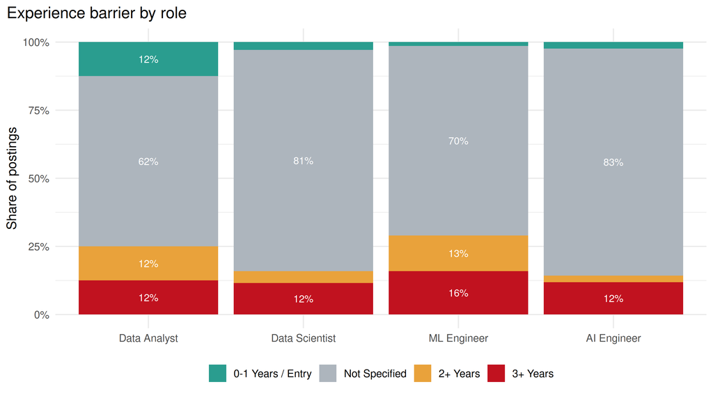

Figure 3: Years of experience requested in verified Intern + Junior postings.

```r
scope |>
  count(normalized_role, experience_tier, .drop = FALSE) |>
  group_by(normalized_role) |>
  mutate(share = n / sum(n)) |>
  ggplot(aes(normalized_role, share, fill = experience_tier)) +
  geom_col() +
  geom_text(aes(label = if_else(share >= 0.05, percent(share, accuracy = 1), "")),
            position = position_stack(vjust = 0.5), size = 3.2, colour = "white") +
  scale_y_continuous(labels = percent) +
  scale_fill_manual(values = c("0-1 Years / Entry" = "#2a9d8f", "Not Specified" = "#adb5bd",
                               "2+ Years" = "#e9a23b", "3+ Years" = "#c1121f"), name = NULL) +
  labs(x = NULL, y = "Share of postings", title = "Experience barrier by role")
```

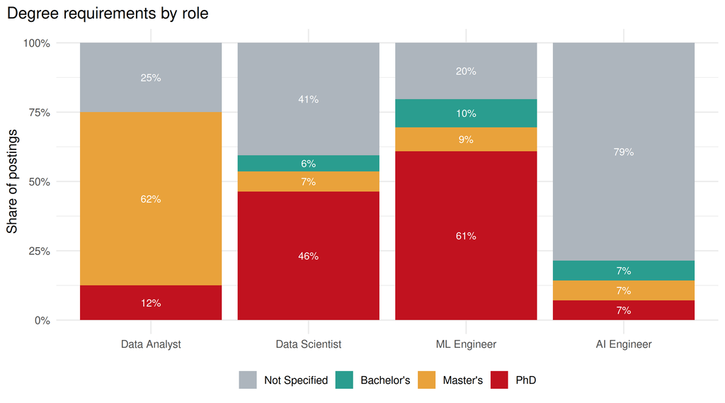

Figure 4: Highest degree level mentioned in verified Intern + Junior postings.

```r
scope |>
  count(normalized_role, degree_tier, .drop = FALSE) |>
  group_by(normalized_role) |>
  mutate(share = n / sum(n)) |>
  ggplot(aes(normalized_role, share, fill = degree_tier)) +
  geom_col() +
  geom_text(aes(label = if_else(share >= 0.05, percent(share, accuracy = 1), "")),
            position = position_stack(vjust = 0.5), size = 3.2, colour = "white") +
  scale_y_continuous(labels = percent) +
  scale_fill_manual(values = c("Not Specified" = "#adb5bd", "Bachelor's" = "#2a9d8f",
                               "Master's" = "#e9a23b", "PhD" = "#c1121f"), name = NULL) +
  labs(x = NULL, y = "Share of postings", title = "Degree requirements by role")
```

```r
scope |>
  group_by(normalized_role) |>
  summarise(
    `In-scope n`            = n(),
    `Asks 2+ yrs`           = percent(mean(experience_tier %in% c("2+ Years", "3+ Years")), accuracy = 0.1),
    `Mentions Master's/PhD` = percent(mean(degree_tier %in% c("Master's", "PhD")), accuracy = 0.1),
    `Mentions PhD`          = percent(mean(degree_tier == "PhD"), accuracy = 0.1),
    .groups = "drop"
  ) |>
  rename(Role = normalized_role) |>
  kable(caption = "Experience and education barrier summary for verified Intern + Junior postings.")
```

Table 4: Experience and education barrier summary for verified Intern + Junior postings.

| Role | In-scope n | Asks 2+ yrs | Mentions Master’s/PhD | Mentions PhD |
| --- | --- | --- | --- | --- |
| Data Analyst | 8 | 25.0% | 75.0% | 12.5% |
| Data Scientist | 69 | 15.9% | 53.6% | 46.4% |
| ML Engineer | 69 | 29.0% | 69.6% | 60.9% |
| AI Engineer | 42 | 14.3% | 14.3% | 7.1% |

# 6 Q4. Compensation and work mode

## 6.1 Salary

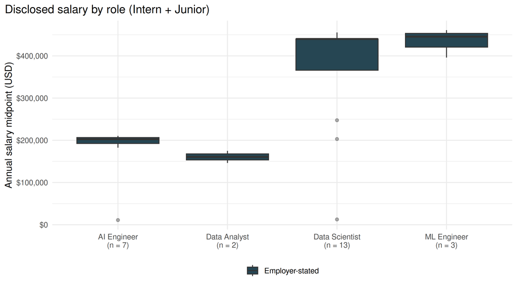

Figure 5: Annual salary midpoint for verified Intern + Junior postings with disclosed pay (n shown under each role).

```r
sal_n <- sal_scope |> count(normalized_role, .drop = FALSE) |>
  mutate(lab = paste0(normalized_role, "\n(n = ", n, ")"))

sal_scope |>
  left_join(sal_n |> select(normalized_role, lab), by = "normalized_role") |>
  ggplot(aes(lab, salary_midpoint, fill = salary_source)) +
  geom_boxplot(outlier.alpha = 0.4, position = position_dodge(preserve = "single")) +
  scale_y_continuous(labels = dollar) +
  scale_fill_manual(values = c("Employer-stated" = "#264653", "API-estimated" = "#e9a23b"),
                    name = NULL) +
  labs(x = NULL, y = "Annual salary midpoint (USD)", title = "Disclosed salary by role (Intern + Junior)")
```

```r
scope |>
  group_by(normalized_role) |>
  summarise(
    `In-scope n`       = n(),
    `Salary disclosed` = percent(mean(has_listed_salary == 1), accuracy = 0.1),
    `Disclosed n`      = sum(has_listed_salary == 1),
    .groups = "drop"
  ) |>
  left_join(
    sal_scope |> group_by(normalized_role) |>
      summarise(`Median salary` = dollar(median(salary_midpoint)),
                .groups = "drop"),
    by = "normalized_role"
  ) |>
  rename(Role = normalized_role) |>
  kable(caption = "Salary disclosure rate and median annualized midpoint across verified Intern + Junior postings.")
```

Table 5: Salary disclosure rate and median annualized midpoint across verified Intern + Junior postings.

| Role | In-scope n | Salary disclosed | Disclosed n | Median salary |
| --- | --- | --- | --- | --- |
| Data Analyst | 8 | 25.0% | 2 | $160,647 |
| Data Scientist | 69 | 18.8% | 13 | $440,000 |
| ML Engineer | 69 | 4.3% | 3 | $445,500 |
| AI Engineer | 42 | 16.7% | 7 | $202,500 |

## 6.2 Work mode

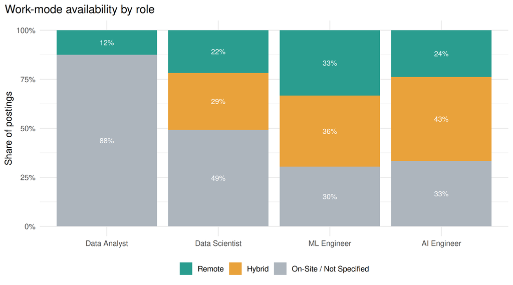

Figure 6: Remote / hybrid / on-site mix in verified Intern + Junior postings.

```r
scope |>
  count(normalized_role, work_mode, .drop = FALSE) |>
  group_by(normalized_role) |>
  mutate(share = n / sum(n)) |>
  ggplot(aes(normalized_role, share, fill = work_mode)) +
  geom_col() +
  geom_text(aes(label = if_else(share >= 0.05, percent(share, accuracy = 1), "")),
            position = position_stack(vjust = 0.5), size = 3.2, colour = "white") +
  scale_y_continuous(labels = percent) +
  scale_fill_manual(values = c("Remote" = "#2a9d8f", "Hybrid" = "#e9a23b",
                               "On-Site / Not Specified" = "#adb5bd"), name = NULL) +
  labs(x = NULL, y = "Share of postings", title = "Work-mode availability by role")
```

# 7 Role scorecard and recommendations

```r
scorecard <- scope |>
  group_by(normalized_role) |>
  summarise(
    postings     = n(),
    pct_0_1      = mean(experience_tier == "0-1 Years / Entry"),
    pct_2plus    = mean(experience_tier %in% c("2+ Years", "3+ Years")),
    pct_adv      = mean(degree_tier %in% c("Master's", "PhD")),
    pct_flexible = mean(work_mode != "On-Site / Not Specified"),
    .groups = "drop"
  ) |>
  left_join(sal_scope |> group_by(normalized_role) |>
              summarise(median_salary = median(salary_midpoint), .groups = "drop"),
            by = "normalized_role")

scorecard |>
  transmute(
    Role                     = normalized_role,
    `Intern/Junior postings` = postings,
    `Explicit 0-1 yr`        = percent(pct_0_1, accuracy = 0.1),
    `Asks 2+ yrs`            = percent(pct_2plus, accuracy = 0.1),
    `Master's/PhD`           = percent(pct_adv, accuracy = 0.1),
    `Remote/Hybrid`          = percent(pct_flexible, accuracy = 0.1),
    `Median salary`          = dollar(median_salary)
  ) |>
  kable(caption = "One-table comparison of the four tracks (verified Intern + Junior full-text scope).")
easiest_entry  <- scorecard |> slice_max(postings, n = 1, with_ties = FALSE) |>
  pull(normalized_role) |> as.character()
lowest_barrier <- scorecard |> mutate(barrier = pct_2plus + pct_adv) |>
  slice_min(barrier, n = 1, with_ties = FALSE) |> pull(normalized_role) |> as.character()
```

Table 6: One-table comparison of the four tracks (verified Intern + Junior full-text scope).

| Role | Intern/Junior postings | Explicit 0-1 yr | Asks 2+ yrs | Master’s/PhD | Remote/Hybrid | Median salary |
| --- | --- | --- | --- | --- | --- | --- |
| Data Analyst | 8 | 12.5% | 25.0% | 75.0% | 12.5% | $160,647 |
| Data Scientist | 69 | 2.9% | 15.9% | 53.6% | 50.7% | $440,000 |
| ML Engineer | 69 | 1.4% | 29.0% | 69.6% | 69.6% | $445,500 |
| AI Engineer | 42 | 2.4% | 14.3% | 14.3% | 66.7% | $202,500 |

# 8 Limitations and data governance

- **Full-text quality gate vs. market breadth:** Filtering `clean_jobs` to `LENGTH(description_snippet) >= 1000` eliminates Adzuna’s ~250-character snippet truncation and dramatically improves skill-extraction recall, but shifts the sample toward tech and AI employers using public ATS boards (Greenhouse, Lever, Ashby) and full-text APIs (The Muse). Consequently, traditional corporate Data Analyst roles are underrepresented (n = 8 in-scope) relative to Data Scientist and ML/AI Engineer roles.
- **Small cell sizes:** Cells with $n < 30$, specifically Data Analyst (n = 8 Intern + Junior) and salary subsets (n = 2 to n = 13 per role), exhibit higher variance and should be read as directional indicators rather than population parameters.
- **Regex precision:** Case-insensitive word-boundary regex (`~*`) flags keyword presence rather than proficiency depth. For example, standalone R (`\mr\M`), git, or rag can occasionally match unrelated acronyms, and `degree_tier` records the highest degree mentioned anywhere in the description (including “Master’s preferred”).
- **Salary disclosure bias:** Public ATS boards frequently omit compensation unless required by state pay-transparency laws (e.g., California, New York, Washington), biasing disclosed medians upward toward coastal tech markets.
- **Ethics & reproducibility:** All records were collected strictly from official public APIs and public ATS JSON endpoints with zero unauthorized web scraping. The entire pipeline (R ingestion $\rightarrow$ PostgreSQL $\rightarrow$ SQL cleaning $\rightarrow$ Quarto rendering) runs deterministically inside Docker Compose.

# 9 Reproducibility

```bash
docker compose up -d
# In the rocker container: run ingestion scripts, SQL cleaning/views, and R/02_export_for_tableau.R
quarto render reports/case_study_report.qmd --output-dir ../docs
```